# 2021研究生赛题 B题 考试成绩评价

### 一、问题描述

> - 问题1：请给出一个能科学、公平地计算研究生课程成绩的数学模型，并解释其合理性；
> - 问题2：利用给出的数学模型计算数据表（研究生成绩.xlsx）中的研究生课程总成绩并给出最终排名

### 二、包的导入和说明

> 1. 导入numpy数学处理工具库与pandas结构化数据处理工具库
> 2. 为了方便后面的数据分析，同时还导入matplotlib.pyplot简单图像工具以及scipy.stats统计分析工具包

```python
import pandas as pd
import numpy as np
import matplotlib.pyplot as plt
from scipy import stats
```

### 三、数据简单处理

> 1. 导入数据源（此处应为'研究生成绩.xlsx'，为了方便程序读取更名为'grade.xlsx'）,并且为了方便数据处理，这里去除了不必要的标题行

```python
df = pd.read_excel('grade.xlsx',header = 2)
df
```

|  | 学号\课程 | 外语（4学分） | 中国特色社会主义理论与实践(2学分） | 自然辨证法(1学分) | 代数学(3学分) | 拓扑学(3学分) | 泛函分析(3学分) | 数值分析(3学分) | 偏微分方程(2学分) | 偏微分方程数值解(2学分) | ... | 多元统计分析(2学分) | 最优化方法(2学分) | 变分法(2学分) | 守恒律方程选讲(2学分) | 高等概率论(2学分) | 数据挖掘(2学分) | 凸分析(2学分) | 数字图像处理(2学分) | 动力系统与遍历论(2学分) | 数学模型(2学分) |
| --- | --- | --- | --- | --- | --- | --- | --- | --- | --- | --- | --- | --- | --- | --- | --- | --- | --- | --- | --- | --- | --- |
| 0 | 1 | 93 | 97 | 65 | 97 | 85 | 63 | 71 | NaN | NaN | ... |  | 73 |  | 100 |  |  | 62 |  |  |  |
| 1 | 2 | 82 | 99 | 99 | 66 | 99 | 99 | 79 | NaN | 84 | ... |  |  |  |  |  |  |  |  | 87 | 81 |
| 2 | 3 | 92 | 65 | 77 | 97 | 92 | 99 | 86 | NaN |  | ... |  |  |  |  | 62 | 62 |  |  |  |  |
| 3 | 4 | 61 | 94 | 98 | 87 | 91 | 90 | 76 | NaN |  | ... |  |  |  |  |  |  | 88 |  |  |  |
| 4 | 5 | 86 | 67 | 88 | 61 | 71 | 61 | 63 | NaN |  | ... |  |  |  |  |  | 76 |  | 63 |  |  |
| ... | ... | ... | ... | ... | ... | ... | ... | ... | ... | ... | ... | ... | ... | ... | ... | ... | ... | ... | ... | ... | ... |
| 100 | 101 | 82 | 95 | 74 | 78 | 62 | 67 | 87 |  |  | ... |  |  |  |  | 68 |  |  |  |  |  |
| 101 | 102 | 73 | 96 | 64 | 100 | 82 | 88 | 100 |  |  | ... | 80 | 60 |  |  |  |  |  |  | 77 | 66 |
| 102 | 103 | 71 | 76 | 79 | 91 | 93 | 64 | 67 |  | 69 | ... |  |  |  |  |  | 85 |  |  |  |  |
| 103 | 104 | 74 | 62 | 81 | 73 | 67 | 68 | 97 |  |  | ... |  | 97 |  |  |  | 86 |  |  |  |  |
| 104 | 105 | 87 | 79 | 97 | 64 | 90 | 90 | 83 |  |  | ... | 75 | 93 |  |  |  |  | 87 |  |  |  |

105 rows × 25 columns

> 1. 为方便数据处理，切片索引，将所有24个学科依次命名为字母'a'-字母'x'，学号列命名为'id'并作为索引

```python
df.columns = ['id']+list('abcdefghijklmnopqrstuvwx')
df.index = df['id']
df = df.drop('id',axis = 1)
df
```

| id | a | b | c | d | e | f | g | h | i | j | ... | o | p | q | r | s | t | u | v | w | x |
| --- | --- | --- | --- | --- | --- | --- | --- | --- | --- | --- | --- | --- | --- | --- | --- | --- | --- | --- | --- | --- | --- |
| 1 | 93 | 97 | 65 | 97 | 85 | 63 | 71 | NaN | NaN | NaN | ... |  | 73 |  | 100 |  |  | 62 |  |  |  |
| 2 | 82 | 99 | 99 | 66 | 99 | 99 | 79 | NaN | 84 |  | ... |  |  |  |  |  |  |  |  | 87 | 81 |
| 3 | 92 | 65 | 77 | 97 | 92 | 99 | 86 | NaN |  | 63 | ... |  |  |  |  | 62 | 62 |  |  |  |  |
| 4 | 61 | 94 | 98 | 87 | 91 | 90 | 76 | NaN |  |  | ... |  |  |  |  |  |  | 88 |  |  |  |
| 5 | 86 | 67 | 88 | 61 | 71 | 61 | 63 | NaN |  |  | ... |  |  |  |  |  | 76 |  | 63 |  |  |
| ... | ... | ... | ... | ... | ... | ... | ... | ... | ... | ... | ... | ... | ... | ... | ... | ... | ... | ... | ... | ... | ... |
| 101 | 82 | 95 | 74 | 78 | 62 | 67 | 87 |  |  |  | ... |  |  |  |  | 68 |  |  |  |  |  |
| 102 | 73 | 96 | 64 | 100 | 82 | 88 | 100 |  |  |  | ... | 80 | 60 |  |  |  |  |  |  | 77 | 66 |
| 103 | 71 | 76 | 79 | 91 | 93 | 64 | 67 |  | 69 | 100 | ... |  |  |  |  |  | 85 |  |  |  |  |
| 104 | 74 | 62 | 81 | 73 | 67 | 68 | 97 |  |  |  | ... |  | 97 |  |  |  | 86 |  |  |  |  |
| 105 | 87 | 79 | 97 | 64 | 90 | 90 | 83 |  |  |  | ... | 75 | 93 |  |  |  |  | 87 |  |  |  |

105 rows × 24 columns

> 1. 结构数据内存在真实值为NaN或' '(两个空格)的空值表示方法，为方便数据处理，以下全处理为常量-1

```python
df2 = df.fillna(-1)                                 #NaN值填充为-1
for x in 'hijklmnopqrstuvwx':                       #穷举所有'  '替换为-1
    df2[x] = [(-1 if (p == '  ') else p) for p in df2[x]]
    num_s = sum(df2[x]>0)
    if num_s < 5:                                   #选修人数少于5人的课剔除（本例中没有少于5人选修的课）
        df2 = df2.drop([x], axis = 1)
df2
```

| id | a | b | c | d | e | f | g | h | i | j | ... | o | p | q | r | s | t | u | v | w | x |
| --- | --- | --- | --- | --- | --- | --- | --- | --- | --- | --- | --- | --- | --- | --- | --- | --- | --- | --- | --- | --- | --- |
| 1 | 93 | 97 | 65 | 97 | 85 | 63 | 71 | -1 | -1 | -1 | ... | -1 | 73 | -1 | 100 | -1 | -1 | 62 | -1 | -1 | -1 |
| 2 | 82 | 99 | 99 | 66 | 99 | 99 | 79 | -1 | 84 | -1 | ... | -1 | -1 | -1 | -1 | -1 | -1 | -1 | -1 | 87 | 81 |
| 3 | 92 | 65 | 77 | 97 | 92 | 99 | 86 | -1 | -1 | 63 | ... | -1 | -1 | -1 | -1 | 62 | 62 | -1 | -1 | -1 | -1 |
| 4 | 61 | 94 | 98 | 87 | 91 | 90 | 76 | -1 | -1 | -1 | ... | -1 | -1 | -1 | -1 | -1 | -1 | 88 | -1 | -1 | -1 |
| 5 | 86 | 67 | 88 | 61 | 71 | 61 | 63 | -1 | -1 | -1 | ... | -1 | -1 | -1 | -1 | -1 | 76 | -1 | 63 | -1 | -1 |
| ... | ... | ... | ... | ... | ... | ... | ... | ... | ... | ... | ... | ... | ... | ... | ... | ... | ... | ... | ... | ... | ... |
| 101 | 82 | 95 | 74 | 78 | 62 | 67 | 87 | -1 | -1 | -1 | ... | -1 | -1 | -1 | -1 | 68 | -1 | -1 | -1 | -1 | -1 |
| 102 | 73 | 96 | 64 | 100 | 82 | 88 | 100 | -1 | -1 | -1 | ... | 80 | 60 | -1 | -1 | -1 | -1 | -1 | -1 | 77 | 66 |
| 103 | 71 | 76 | 79 | 91 | 93 | 64 | 67 | -1 | 69 | 100 | ... | -1 | -1 | -1 | -1 | -1 | 85 | -1 | -1 | -1 | -1 |
| 104 | 74 | 62 | 81 | 73 | 67 | 68 | 97 | -1 | -1 | -1 | ... | -1 | 97 | -1 | -1 | -1 | 86 | -1 | -1 | -1 | -1 |
| 105 | 87 | 79 | 97 | 64 | 90 | 90 | 83 | -1 | -1 | -1 | ... | 75 | 93 | -1 | -1 | -1 | -1 | 87 | -1 | -1 | -1 |

105 rows × 24 columns

### 四、数据简单分析

> - 考虑到广大学生的任何一门科目的成绩如果在大样本，并且打分标准明确的情况下应当是大致符合正态分布的
> - 正态分布普遍的检验方式有两种S-W检验以及K-S检验，S-W检验一般适合5000以下的小样本，而K-S检验一般适用于5000以上的大样本
> - 本例中学生人数仅有105人，所以考虑用S-W检验（python语言中为shapiro检验）

```python
pvalue_lst = []
for x in 'abcdefghijklmnopqrstuvwx':
    S_W_Result = stats.shapiro(df2[x][df2[x]>0])
    print(f'{x}科目总共有{len(df2[x][df2[x]>0])}个有效学生成绩，经S-W检验得到:')
    S_W_statistic = format(S_W_Result.statistic,'.5f')
    S_W_pvalue = format(S_W_Result.pvalue,'.5f')
    print(f'统计量-> {S_W_statistic}\np值   -> {S_W_pvalue}\n')
    pvalue_lst.append(S_W_Result.pvalue)
```

```
a科目总共有105个有效学生成绩，经S-W检验得到:
统计量-> 0.95566
p值   -> 0.00146

b科目总共有105个有效学生成绩，经S-W检验得到:
统计量-> 0.95779
p值   -> 0.00207

c科目总共有105个有效学生成绩，经S-W检验得到:
统计量-> 0.94723
p值   -> 0.00038

d科目总共有105个有效学生成绩，经S-W检验得到:
统计量-> 0.97052
p值   -> 0.01925

e科目总共有105个有效学生成绩，经S-W检验得到:
统计量-> 0.94337
p值   -> 0.00021

f科目总共有105个有效学生成绩，经S-W检验得到:
统计量-> 0.93761
p值   -> 0.00009

g科目总共有105个有效学生成绩，经S-W检验得到:
统计量-> 0.94478
p值   -> 0.00026

h科目总共有23个有效学生成绩，经S-W检验得到:
统计量-> 0.96482
p值   -> 0.56715

i科目总共有23个有效学生成绩，经S-W检验得到:
统计量-> 0.68613
p值   -> 0.00001

j科目总共有24个有效学生成绩，经S-W检验得到:
统计量-> 0.90538
p值   -> 0.02804

```

[output cut: 40 more lines]

```
u科目总共有24个有效学生成绩，经S-W检验得到:
统计量-> 0.94068
p值   -> 0.16889

v科目总共有27个有效学生成绩，经S-W检验得到:
统计量-> 0.92517
p值   -> 0.05267

w科目总共有19个有效学生成绩，经S-W检验得到:
统计量-> 0.92447
p值   -> 0.13690

x科目总共有28个有效学生成绩，经S-W检验得到:
统计量-> 0.94246
p值   -> 0.12766
```

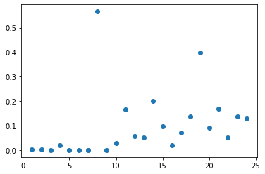

```python
x = range(1,len(pvalue_lst)+1)
plt.scatter(x,pvalue_lst)
```

### 五、模型建立

> - 单独采用学分加权方式计算综合成绩会忽视学科难度带来的低分惩罚
> - 而单独利用学科简单平均分的倒数作为权数加权也会有两点问题
>   1. 简单平均分容易受极端值影响
>   2. 无法同时考虑到学分权重问题
> - 所以这里采用改良模型来统计综合成绩 【改良模型：根据科目难度统一规范调整下成绩的学分加权平均模型】
> 1. 一般的根据正态分布拟合会直接采用数据的算数平均值拟合为正态分布的均值，这里会再次出现受极端值影响的问题，这里采用另外一种方式取整体数据的理论均值：
>    1. 取某科目的最低与最高成绩，分别记为a,b
>    2. 对处于[a,b]区间的数据分别做组数为4-9的直方图数据统计
>    3. 对组数为4-9的直方图数据分别做最大数据组与第二大数据组的差，选取差最大的直方图数据作为备选数据
>    4. 这一步是考虑到正态分布基本图形为钟形曲线，均值与附近的值之间的曲线斜率很大（降速很快），所以通过组别作差的方式选取最能代表正态分布的分组模式，并将其有最多数据分布的区间中点取为我们最终想要进行科目成绩难度统一规范调整的调整参数（理论均值）
> 2. 计算出理论均值之后，这里为了避免出现调整后成绩小于0或大于100的情况出现，这里采用等比例分别放缩处在理论均值两侧的成绩，具体步骤如下：
>    1. 等比例放缩是为了使得原本处在0至理论均值之间的成绩之间差距所构成的比例，在放缩调整之后这个比例依然不变（理论均值至100区间内的成绩也同理）
>    2. 为了达到此效果这里采用的算法是：
>       - （将0至理论均值之间的成绩记为$ a_{i} $，调整后的记为$ a_{i}^{*} $，将理论均值至100之间的成绩记为$ b_{i} $,调整后的记为$ b_{i}^{*} $，理论均值记为$ mean $,）
>       1. $ a_{i}^{*} = \dfrac{a_{i}\times 80}{mean} $
>       2. $ b_{i}^{*} = 100-\left( 100-b_{i}\right) \times \dfrac{20}{100-mean} $
>       3. 这样的结果是可以成功的将每一门科目的理论均值调整至80分，以达到每门科目成绩调整之后的难度程度统一
>       4. 这里是根据直觉经验选取的80作为调整后的理论均值（当然也可以选取60、70、75等其他值，结果略有不同）

```python
for x in 'abcdefghijklmnopqrstuvwx':
    print(f'######## {x}科目的处理过程：################')
    print(f'【数据特征】：\n>>>>>>>>>>>：{x}科目的简单算数平均成绩为：{np.mean(df2[x][df2[x]>0])}')
    a, b = np.min(df2[x][df2[x]>0]), np.max(df2[x][df2[x]>0])   #五-1-A
    print(f'>>>>>>>>>>>：{x}科目的有效成绩区间为：[{a},{b}]\n')
    print('【最优分组选取】：\n>>>>>>>>>>>>>>：---------------------------------------')
    gap_lst = [0,0,0,0]
    try_gap_lst = [0,0,0,0]
    for i in range(4,10):                                       #五-1-B
        a_lst = [len(df2[x][df2[x]>=(a+n*(b-a)/i)]) for n in range(i)]
        a_lst = list(map(lambda x,y: x-y,a_lst,a_lst[1:]+[0]))
        try_gap_lst.append(a_lst)
        b_lst = a_lst.copy()
        b_lst.sort(reverse=1)
        max_gap = b_lst[0] - b_lst[1]                           #五-1-C  作差
        gap_lst.append(max_gap)
        print(f'>>>>>>>>>>>>>>：组数为{i}的每组容量分别为：{a_lst}，最大组容与次大组容差为：{max_gap}')
    best_n = gap_lst.index(np.max(gap_lst))                     #五-1-C  选最优分组法
    best_try_lst = try_gap_lst[best_n]
    print('>>>>>>>>>>>>>>：---------------------------------------')
    print(f'>>>>>>>>>>>>>>：经筛选，最佳的分组是组数为{best_n}的分组:{best_try_lst}\n')
    print(f'【理论均值求解】：\n>>>>>>>>>>>>>>：求值表达式为：{a} + ({b} - {a}) / {best_n} * (0.5 + {best_try_lst.index(np.max(best_try_lst))})')
    best_mid = a + (b-a)/best_n*(0.5+best_try_lst.index(np.max(best_try_lst)))           #五-1-D  求解理论均值
    print(f'>>>>>>>>>>>>>>：理论均值为{best_mid}\n')
    print(f'【成绩调整】\n>>>>>>>>>>>：公式一：ai* = ai * 80 / {best_mid}')
    print(f'>>>>>>>>>>>：公式二：bi* = 100 - (100 - bi) * 20 / (100 - {best_mid})')
    print('#########################################\n\n')
    mask_a = (df2[x]>0)&(df2[x]<=best_mid)
    df2.loc[mask_a,(x)] = (df2.loc[mask_a,(x)]/best_mid*80)     #五-2-B-a
    mask_b = df2[x]>best_mid
    df2.loc[mask_b,(x)] = (100 - (100 - df2.loc[mask_b,(x)])/(100 - best_mid)*20)        #五-2-B-b
df2
```

```
######## a科目的处理过程：################
【数据特征】：
>>>>>>>>>>>：a科目的简单算数平均成绩为：81.35238095238095
>>>>>>>>>>>：a科目的有效成绩区间为：[60,100]

【最优分组选取】：
>>>>>>>>>>>>>>：---------------------------------------
>>>>>>>>>>>>>>：组数为4的每组容量分别为：[21, 22, 29, 33]，最大组容与次大组容差为：4
>>>>>>>>>>>>>>：组数为5的每组容量分别为：[15, 21, 21, 25, 23]，最大组容与次大组容差为：2
>>>>>>>>>>>>>>：组数为6的每组容量分别为：[12, 18, 13, 20, 27, 15]，最大组容与次大组容差为：7
>>>>>>>>>>>>>>：组数为7的每组容量分别为：[10, 15, 13, 18, 13, 25, 11]，最大组容与次大组容差为：7
>>>>>>>>>>>>>>：组数为8的每组容量分别为：[8, 13, 11, 11, 16, 13, 22, 11]，最大组容与次大组容差为：6
>>>>>>>>>>>>>>：组数为9的每组容量分别为：[8, 9, 13, 8, 18, 7, 19, 14, 9]，最大组容与次大组容差为：1
>>>>>>>>>>>>>>：---------------------------------------
>>>>>>>>>>>>>>：经筛选，最佳的分组是组数为6的分组:[12, 18, 13, 20, 27, 15]

【理论均值求解】：
>>>>>>>>>>>>>>：求值表达式为：60 + (100 - 60) / 6 * (0.5 + 4)
>>>>>>>>>>>>>>：理论均值为90.0

【成绩调整】
>>>>>>>>>>>：公式一：ai* = ai * 80 / 90.0
>>>>>>>>>>>：公式二：bi* = 100 - (100 - bi) * 20 / (100 - 90.0)
#########################################


######## b科目的处理过程：################
【数据特征】：
>>>>>>>>>>>：b科目的简单算数平均成绩为：78.32380952380953
>>>>>>>>>>>：b科目的有效成绩区间为：[61,100]

【最优分组选取】：
>>>>>>>>>>>>>>：---------------------------------------
>>>>>>>>>>>>>>：组数为4的每组容量分别为：[31, 31, 26, 17]，最大组容与次大组容差为：0
>>>>>>>>>>>>>>：组数为5的每组容量分别为：[24, 25, 23, 18, 15]，最大组容与次大组容差为：1
>>>>>>>>>>>>>>：组数为6的每组容量分别为：[22, 20, 20, 14, 15, 14]，最大组容与次大组容差为：2
>>>>>>>>>>>>>>：组数为7的每组容量分别为：[17, 21, 15, 17, 13, 11, 11]，最大组容与次大组容差为：4
>>>>>>>>>>>>>>：组数为8的每组容量分别为：[14, 17, 16, 15, 13, 13, 7, 10]，最大组容与次大组容差为：1
>>>>>>>>>>>>>>：组数为9的每组容量分别为：[14, 13, 15, 15, 10, 9, 12, 7, 10]，最大组容与次大组容差为：0
>>>>>>>>>>>>>>：---------------------------------------
```

[output cut: 567 more lines]

```
>>>>>>>>>>>>>>：组数为6的每组容量分别为：[5, 4, 2, 7, 4, 6]，最大组容与次大组容差为：1
>>>>>>>>>>>>>>：组数为7的每组容量分别为：[4, 5, 1, 6, 4, 2, 6]，最大组容与次大组容差为：0
>>>>>>>>>>>>>>：组数为8的每组容量分别为：[2, 6, 1, 2, 7, 3, 1, 6]，最大组容与次大组容差为：1
>>>>>>>>>>>>>>：组数为9的每组容量分别为：[2, 5, 2, 2, 4, 3, 3, 1, 6]，最大组容与次大组容差为：1
>>>>>>>>>>>>>>：---------------------------------------
>>>>>>>>>>>>>>：经筛选，最佳的分组是组数为4的分组:[8, 3, 10, 7]

【理论均值求解】：
>>>>>>>>>>>>>>：求值表达式为：61 + (100 - 61) / 4 * (0.5 + 2)
>>>>>>>>>>>>>>：理论均值为85.375

【成绩调整】
>>>>>>>>>>>：公式一：ai* = ai * 80 / 85.375
>>>>>>>>>>>：公式二：bi* = 100 - (100 - bi) * 20 / (100 - 85.375)
#########################################
```

| id | a | b | c | d | e | f | g | h | i | j | ... | o | p | q | r | s | t | u | v | w | x |
| --- | --- | --- | --- | --- | --- | --- | --- | --- | --- | --- | --- | --- | --- | --- | --- | --- | --- | --- | --- | --- | --- |
| 1 | 86.000000 | 98.041958 | 54.736842 | 97.0 | 71.578947 | 58.800000 | 81.545455 | -1.0 | -1.000000 | -1.000000 | ... | -1.000000 | 60.833333 | -1.0 | 100.0 | -1.000000 | -1.000000 | 51.058824 | -1.000000 | -1.000000 | -1.000000 |
| 2 | 72.888889 | 99.347319 | 96.000000 | 66.0 | 96.000000 | 98.600000 | 86.636364 | -1.0 | 84.197531 | -1.000000 | ... | -1.000000 | -1.000000 | -1.0 | -1.0 | -1.000000 | -1.000000 | -1.000000 | -1.000000 | 72.374350 | 75.900439 |
| 3 | 84.000000 | 83.666179 | 64.842105 | 97.0 | 77.473684 | 98.600000 | 91.090909 | -1.0 | -1.000000 | 88.194444 | ... | -1.000000 | -1.000000 | -1.0 | -1.0 | 65.986696 | 52.100840 | -1.000000 | -1.000000 | -1.000000 | -1.000000 |
| 4 | 54.222222 | 96.083916 | 92.000000 | 87.0 | 76.631579 | 86.000000 | 84.727273 | -1.0 | -1.000000 | -1.000000 | ... | -1.000000 | -1.000000 | -1.0 | -1.0 | -1.000000 | -1.000000 | 72.470588 | -1.000000 | -1.000000 | -1.000000 |
| 5 | 76.444444 | 85.171848 | 74.105263 | 61.0 | 59.789474 | 56.933333 | 83.136364 | -1.0 | -1.000000 | -1.000000 | ... | -1.000000 | -1.000000 | -1.0 | -1.0 | -1.000000 | 63.865546 | -1.000000 | 87.425724 | -1.000000 | -1.000000 |
| ... | ... | ... | ... | ... | ... | ... | ... | ... | ... | ... | ... | ... | ... | ... | ... | ... | ... | ... | ... | ... | ... |
| 101 | 72.888889 | 96.736597 | 62.315789 | 78.0 | 52.210526 | 62.533333 | 91.727273 | -1.0 | -1.000000 | -1.000000 | ... | -1.000000 | -1.000000 | -1.0 | -1.0 | 72.372506 | -1.000000 | -1.000000 | -1.000000 | -1.000000 | -1.000000 |
| 102 | 64.888889 | 97.389277 | 53.894737 | 100.0 | 69.052632 | 83.200000 | 100.000000 | -1.0 | -1.000000 | -1.000000 | ... | 84.962406 | 50.000000 | -1.0 | -1.0 | -1.000000 | -1.000000 | -1.000000 | -1.000000 | 64.055459 | 61.844802 |
| 103 | 63.111111 | 84.335664 | 66.526316 | 91.0 | 78.315789 | 59.733333 | 86.106061 | -1.0 | 69.216301 | 100.000000 | ... | -1.000000 | -1.000000 | -1.0 | -1.0 | -1.000000 | 71.428571 | -1.000000 | -1.000000 | -1.000000 | -1.000000 |
| 104 | 65.777778 | 81.407676 | 68.210526 | 73.0 | 56.421053 | 63.466667 | 98.090909 | -1.0 | -1.000000 | -1.000000 | ... | -1.000000 | 85.000000 | -1.0 | -1.0 | -1.000000 | 72.268908 | -1.000000 | -1.000000 | -1.000000 | -1.000000 |
| 105 | 77.333333 | 86.293706 | 88.000000 | 64.0 | 75.789474 | 86.000000 | 89.181818 | -1.0 | -1.000000 | -1.000000 | ... | 81.203008 | 77.500000 | -1.0 | -1.0 | -1.000000 | -1.000000 | 71.647059 | -1.000000 | -1.000000 | -1.000000 |

105 rows × 24 columns

1. 为了综合考察根据科目难度调整完的成绩，我们对调整完的数据再进行学分加权平均（未选修的科目不参与加权，0分科目参与加权）

```python
#构建加权函数
def col_g_w_sum(s_g):
    w_sum = sum(map(lambda x,y: x*y,s_g[0:7],[4,2,1,3,3,3,3])) + sum([(x*2 if x>0 else 0) for x in s_g[7:]])
    Total_g = sum([4,2,1,3,3,3,3])+sum([(2 if x>=0 else 0) for x in s_g[7:]])
    return w_sum/Total_g
```

```python
#应用加权函数对每行的列数据加权，结果保留两位小数
df2['s_w_grade'] = df2.apply(lambda x: format(col_g_w_sum(x), '.2f'), axis=1)
df2
```

| id | a | b | c | d | e | f | g | h | i | j | ... | p | q | r | s | t | u | v | w | x | s_w_grade |
| --- | --- | --- | --- | --- | --- | --- | --- | --- | --- | --- | --- | --- | --- | --- | --- | --- | --- | --- | --- | --- | --- |
| 1 | 86.000000 | 98.041958 | 54.736842 | 97.0 | 71.578947 | 58.800000 | 81.545455 | -1.0 | -1.000000 | -1.000000 | ... | 60.833333 | -1.0 | 100.0 | -1.000000 | -1.000000 | 51.058824 | -1.000000 | -1.000000 | -1.000000 | 78.22 |
| 2 | 72.888889 | 99.347319 | 96.000000 | 66.0 | 96.000000 | 98.600000 | 86.636364 | -1.0 | 84.197531 | -1.000000 | ... | -1.000000 | -1.0 | -1.0 | -1.000000 | -1.000000 | -1.000000 | -1.000000 | 72.374350 | 75.900439 | 84.43 |
| 3 | 84.000000 | 83.666179 | 64.842105 | 97.0 | 77.473684 | 98.600000 | 91.090909 | -1.0 | -1.000000 | 88.194444 | ... | -1.000000 | -1.0 | -1.0 | 65.986696 | 52.100840 | -1.000000 | -1.000000 | -1.000000 | -1.000000 | 83.75 |
| 4 | 54.222222 | 96.083916 | 92.000000 | 87.0 | 76.631579 | 86.000000 | 84.727273 | -1.0 | -1.000000 | -1.000000 | ... | -1.000000 | -1.0 | -1.0 | -1.000000 | -1.000000 | 72.470588 | -1.000000 | -1.000000 | -1.000000 | 78.18 |
| 5 | 76.444444 | 85.171848 | 74.105263 | 61.0 | 59.789474 | 56.933333 | 83.136364 | -1.0 | -1.000000 | -1.000000 | ... | -1.000000 | -1.0 | -1.0 | -1.000000 | 63.865546 | -1.000000 | 87.425724 | -1.000000 | -1.000000 | 72.04 |
| ... | ... | ... | ... | ... | ... | ... | ... | ... | ... | ... | ... | ... | ... | ... | ... | ... | ... | ... | ... | ... | ... |
| 101 | 72.888889 | 96.736597 | 62.315789 | 78.0 | 52.210526 | 62.533333 | 91.727273 | -1.0 | -1.000000 | -1.000000 | ... | -1.000000 | -1.0 | -1.0 | 72.372506 | -1.000000 | -1.000000 | -1.000000 | -1.000000 | -1.000000 | 75.62 |
| 102 | 64.888889 | 97.389277 | 53.894737 | 100.0 | 69.052632 | 83.200000 | 100.000000 | -1.0 | -1.000000 | -1.000000 | ... | 50.000000 | -1.0 | -1.0 | -1.000000 | -1.000000 | -1.000000 | -1.000000 | 64.055459 | 61.844802 | 77.29 |
| 103 | 63.111111 | 84.335664 | 66.526316 | 91.0 | 78.315789 | 59.733333 | 86.106061 | -1.0 | 69.216301 | 100.000000 | ... | -1.000000 | -1.0 | -1.0 | -1.000000 | 71.428571 | -1.000000 | -1.000000 | -1.000000 | -1.000000 | 77.36 |
| 104 | 65.777778 | 81.407676 | 68.210526 | 73.0 | 56.421053 | 63.466667 | 98.090909 | -1.0 | -1.000000 | -1.000000 | ... | 85.000000 | -1.0 | -1.0 | -1.000000 | 72.268908 | -1.000000 | -1.000000 | -1.000000 | -1.000000 | 74.02 |
| 105 | 77.333333 | 86.293706 | 88.000000 | 64.0 | 75.789474 | 86.000000 | 89.181818 | -1.0 | -1.000000 | -1.000000 | ... | 77.500000 | -1.0 | -1.0 | -1.000000 | -1.000000 | 71.647059 | -1.000000 | -1.000000 | -1.000000 | 80.02 |

105 rows × 25 columns

### 六、数据结果导出

```python
df['s_w_grade'] = df2['s_w_grade']
df
```

| id | a | b | c | d | e | f | g | h | i | j | ... | p | q | r | s | t | u | v | w | x | s_w_grade |
| --- | --- | --- | --- | --- | --- | --- | --- | --- | --- | --- | --- | --- | --- | --- | --- | --- | --- | --- | --- | --- | --- |
| 1 | 93 | 97 | 65 | 97 | 85 | 63 | 71 | NaN | NaN | NaN | ... | 73 |  | 100 |  |  | 62 |  |  |  | 78.22 |
| 2 | 82 | 99 | 99 | 66 | 99 | 99 | 79 | NaN | 84 |  | ... |  |  |  |  |  |  |  | 87 | 81 | 84.43 |
| 3 | 92 | 65 | 77 | 97 | 92 | 99 | 86 | NaN |  | 63 | ... |  |  |  | 62 | 62 |  |  |  |  | 83.75 |
| 4 | 61 | 94 | 98 | 87 | 91 | 90 | 76 | NaN |  |  | ... |  |  |  |  |  | 88 |  |  |  | 78.18 |
| 5 | 86 | 67 | 88 | 61 | 71 | 61 | 63 | NaN |  |  | ... |  |  |  |  | 76 |  | 63 |  |  | 72.04 |
| ... | ... | ... | ... | ... | ... | ... | ... | ... | ... | ... | ... | ... | ... | ... | ... | ... | ... | ... | ... | ... | ... |
| 101 | 82 | 95 | 74 | 78 | 62 | 67 | 87 |  |  |  | ... |  |  |  | 68 |  |  |  |  |  | 75.62 |
| 102 | 73 | 96 | 64 | 100 | 82 | 88 | 100 |  |  |  | ... | 60 |  |  |  |  |  |  | 77 | 66 | 77.29 |
| 103 | 71 | 76 | 79 | 91 | 93 | 64 | 67 |  | 69 | 100 | ... |  |  |  |  | 85 |  |  |  |  | 77.36 |
| 104 | 74 | 62 | 81 | 73 | 67 | 68 | 97 |  |  |  | ... | 97 |  |  |  | 86 |  |  |  |  | 74.02 |
| 105 | 87 | 79 | 97 | 64 | 90 | 90 | 83 |  |  |  | ... | 93 |  |  |  |  | 87 |  |  |  | 80.02 |

105 rows × 25 columns

```python
df_Sorted = df.sort_values(axis=0,ascending=False,by=['s_w_grade'])
df_Sorted
```

| id | a | b | c | d | e | f | g | h | i | j | ... | p | q | r | s | t | u | v | w | x | s_w_grade |
| --- | --- | --- | --- | --- | --- | --- | --- | --- | --- | --- | --- | --- | --- | --- | --- | --- | --- | --- | --- | --- | --- |
| 87 | 98 | 88 | 83 | 93 | 96 | 100 | 60 |  |  |  | ... | 100 |  |  |  |  |  |  | 96 |  | 89.83 |
| 56 | 100 | 89 | 74 | 83 | 64 | 97 | 96 |  | 90 |  | ... |  |  | 98 |  |  |  | 62 |  |  | 88.09 |
| 98 | 89 | 90 | 62 | 95 | 98 | 100 | 95 |  |  | 65 | ... | 79 |  |  |  |  |  |  |  |  | 86.26 |
| 2 | 82 | 99 | 99 | 66 | 99 | 99 | 79 | NaN | 84 |  | ... |  |  |  |  |  |  |  | 87 | 81 | 84.43 |
| 17 | 69 | 97 | 66 | 93 | 82 | 100 | 63 |  |  |  | ... |  |  |  |  |  |  |  |  | 89 | 84.06 |
| ... | ... | ... | ... | ... | ... | ... | ... | ... | ... | ... | ... | ... | ... | ... | ... | ... | ... | ... | ... | ... | ... |
| 16 | 84 | 70 | 86 | 88 | 90 | 78 | 63 |  | 1 |  | ... |  |  |  |  |  | 76 | 98 |  |  | 72.90 |
| 5 | 86 | 67 | 88 | 61 | 71 | 61 | 63 | NaN |  |  | ... |  |  |  |  | 76 |  | 63 |  |  | 72.04 |
| 57 | 93 | 70 | 84 | 60 | 77 | 72 | 66 |  |  |  | ... |  |  |  |  |  | 90 |  | 84 | 66 | 71.47 |
| 85 | 92 | 73 | 81 | 63 | 64 | 65 | 87 |  |  |  | ... |  |  |  |  |  | 60 | 77 | 73 | 82 | 71.28 |
| 97 | 64 | 65 | 66 | 85 | 83 | 62 | 98 |  |  |  | ... | 62 |  |  |  |  |  |  | 65 | 78 | 70.88 |

105 rows × 25 columns

```python
df_Sorted.to_excel('Result.xlsx')
```